Data Analysis · MBAA 531

# Experience Pays, But Not Equally

Salary rises with experience in the talent market, but education level explains surprisingly little of who earns more.

By Kaur Navdeep · Dataset: Talent Market Compensation Survey

## The Data

This analysis draws on the Talent Market Compensation Survey, a dataset of 23,876 workers across 12 roles and 10 industries. Each row represents one individual respondent, capturing their annual salary in USD, years of experience, education level, number of skills, industry, company size, country, remote-work status, and certifications.

The dataset spans five education tiers from High School to PhD, and ten industries including Finance, Technology, Healthcare, and Retail. Salaries range from around $41,000 to $328,000, with a median of $143,132. The diversity of roles and industries makes this dataset well suited for exploring what actually predicts compensation in today’s talent market.

One column, experience_band, was absent from the raw CSV and was recreated by grouping experience_yrs into four career stages: Junior (0–3 years), Mid (4–9), Senior (10–15), and Principal (16–20). The education column was also converted from plain text to an ordered factor to preserve the credential hierarchy in analysis.

## The Central Finding

To move beyond raw salary, this analysis created a derived variable called salary_per_exp_yr — calculated as salary_usd divided by experience_yrs plus one. Adding one to the denominator prevents division by zero for respondents with no experience. This variable measures earnings efficiency: how many dollars of annual salary a worker commands per year of career experience.

$13,403 Median dollars earned per year of experience — the typical worker’s earnings efficiency in this talent market.

A median of $13,403 per year of experience means a typical worker earns roughly $13,400 in annual salary for each year of career experience they bring to a role. This number compresses both salary and seniority into a single measure, making it easier to compare workers across different career stages. A higher value means the market is rewarding experience more generously; a lower value suggests experience alone is not the main driver of pay.

## A Closer Look

If experience drives salary, we would expect a clear upward trend in a scatter plot of the two variables — workers with more years in the field earning progressively more. The chart below tests that expectation across all 23,876 respondents.

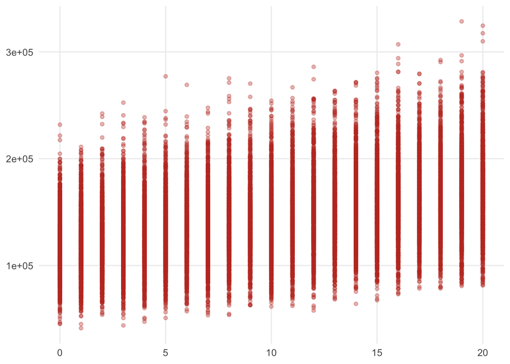

Chart 1: Salary (USD) plotted against years of experience for 23,876 respondents. Each point is one worker.

The upward trend is visible but the spread is wide — workers at every experience level show a broad range of salaries. This tells us experience is one ingredient in compensation, but far from the only one.

## Across Groups

Education level is widely assumed to sort workers into distinct salary bands. A PhD or Master’s degree is expected to command a premium over a High School diploma or Diploma credential. The ridge chart below shows the full salary distribution for each of the five education tiers, making it easy to see whether the peaks actually shift as credentials increase.

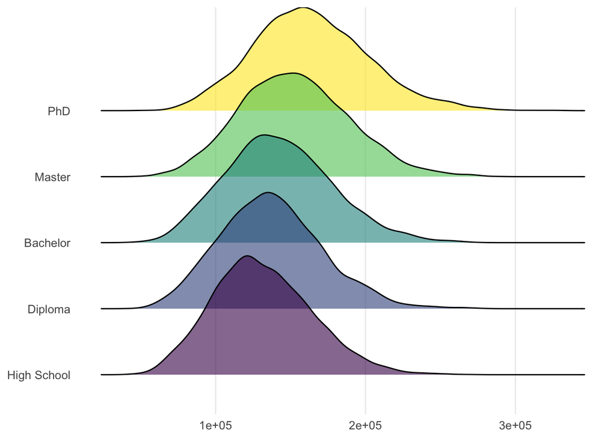

Chart 2: Salary distribution by education level. Each ridge shows the density of salaries for one credential tier.

## What This Means

The headline claim holds up: experience pays, but not equally, and the credential you hold matters less than many workers assume. The scatter chart shows a genuine upward trend between experience and salary, confirming that time in the field does translate into higher pay on average. But the wide spread at every experience level means two workers with identical tenure can earn vastly different salaries depending on their role, industry, or other factors the data does not fully capture.

For a decision-maker in talent acquisition or workforce planning, these two findings together suggest that years of experience is a more reliable signal of compensation than education level. Salary benchmarking built primarily around credential tiers may be missing the variable that actually predicts pay. What the data leaves unanswered is why the education premium is so muted — whether that reflects the industries sampled, the roles included, or a genuine shift in how the market values credentials.